# MLS4001: Estatística Aplicada à Medicina

## Histograma

- Silveira, PSP & Siqueira, JO (2022) Histogram lies about distribution shape and Pearson’s coefficient of variation lies about relative variability. [*The Quantitative Methods for Psychology*](https://www.tqmp.org/RegularArticles/vol18-1/p091/p091.pdf) 18(1). [DOI 10.20982/tqmp.18.1.p091](https://www.tqmp.org/RegularArticles/vol18-1/p091/)
- How to Lie with Histograms
  - https://www.rossidata.com/LinLog

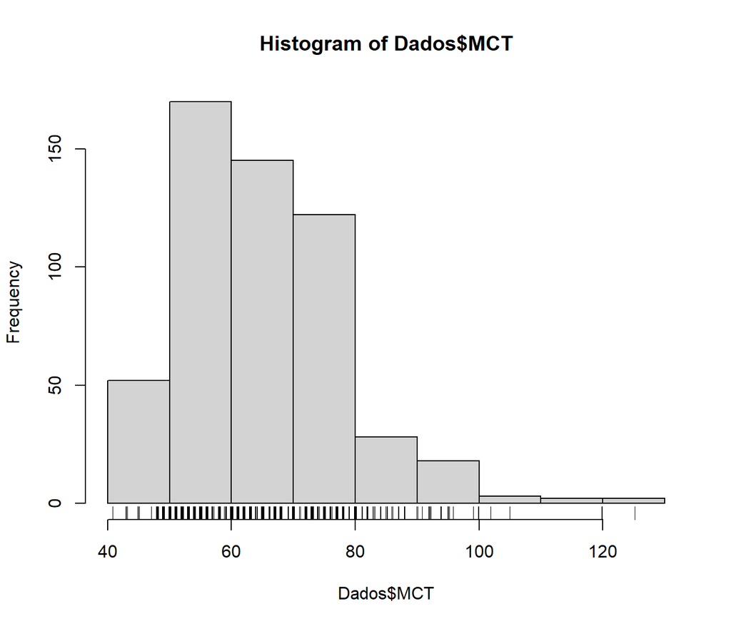

```r
hist(Dados$MCT)
rug(jitter(Dados$MCT))
```

## Gráfico de densidade

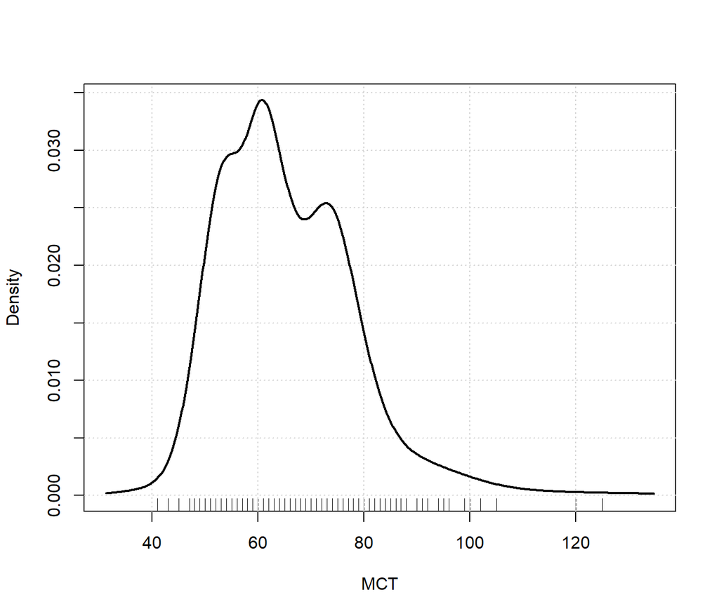

```r
car::densityPlot(~MCT, data=Dados)
```

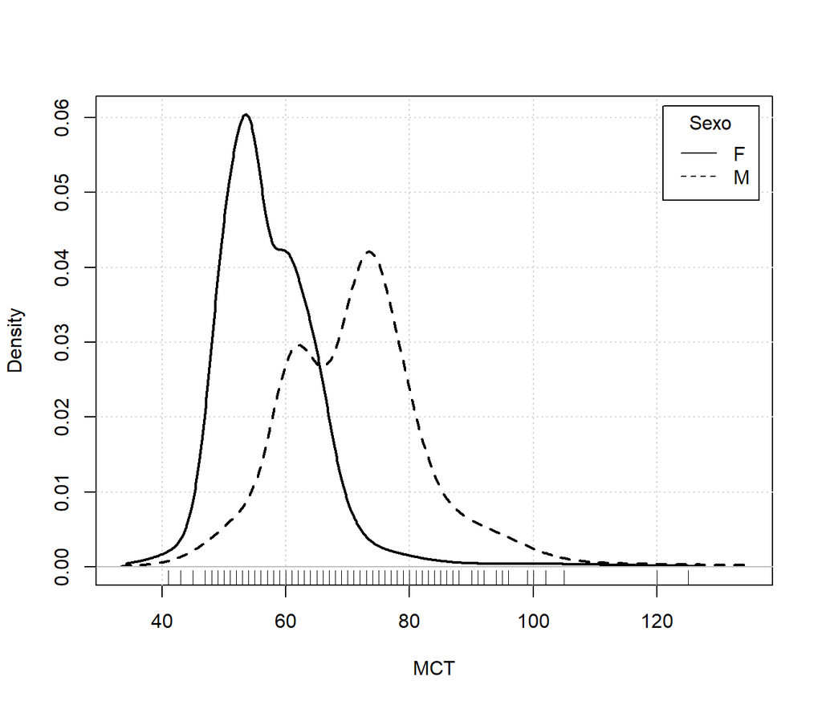

```r
car::densityPlot(MCT~Sexo, data=Dados,
                 col=c("black","black"))
```

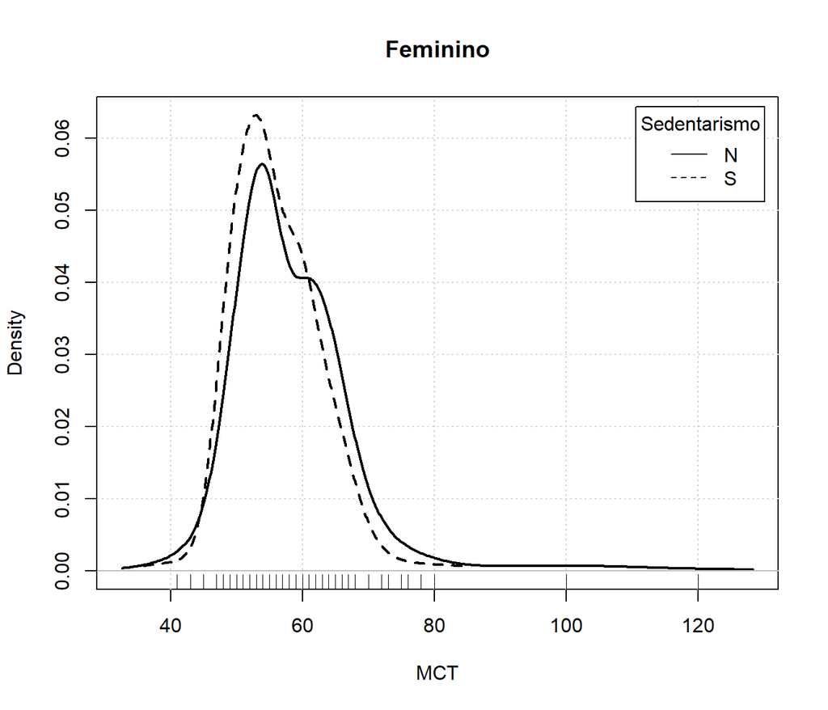

```r
car::densityPlot(MCT~Sedentarismo, data=Dados.F,
                 col=c("black","black"),
                 main="Feminino")
```

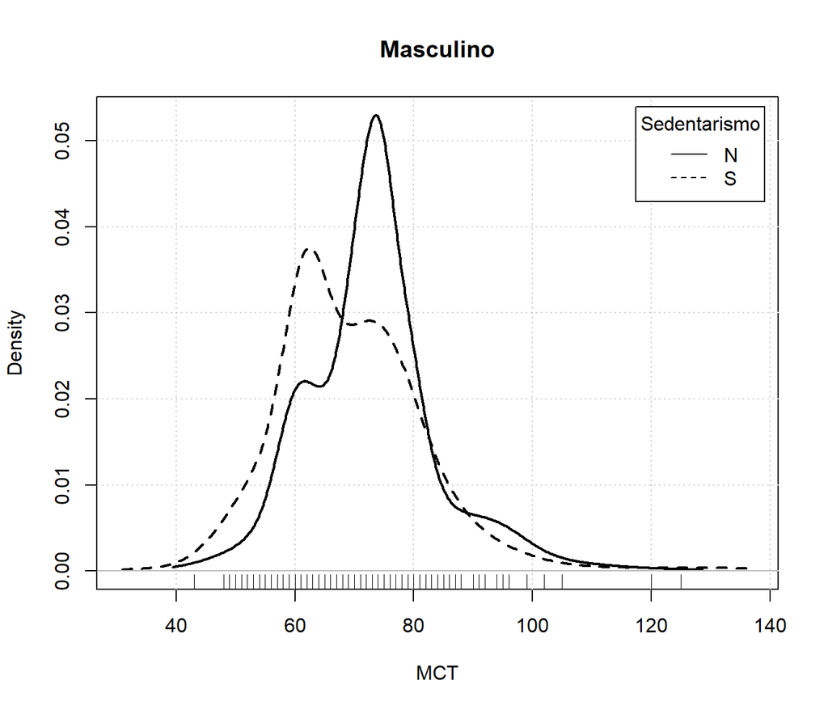

```r
car::densityPlot(MCT~Sedentarismo, data=Dados.M,
                 col=c("black","black"),
                 main="Masculino")
```

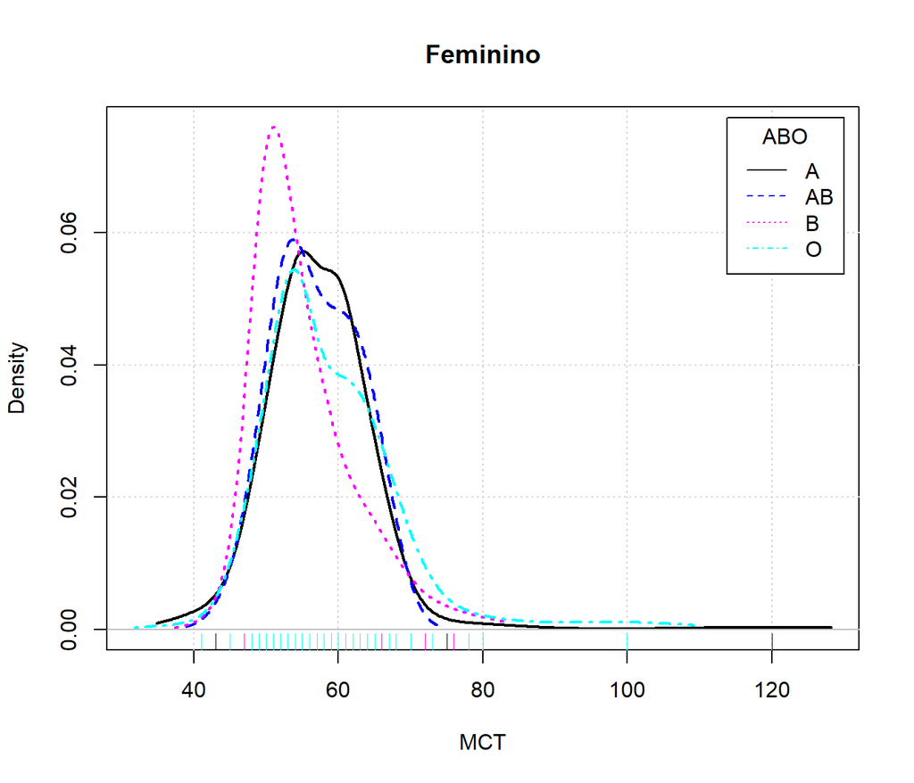

```r
car::densityPlot(MCT~ABO, data=Dados.F,
                 main="Feminino")
```

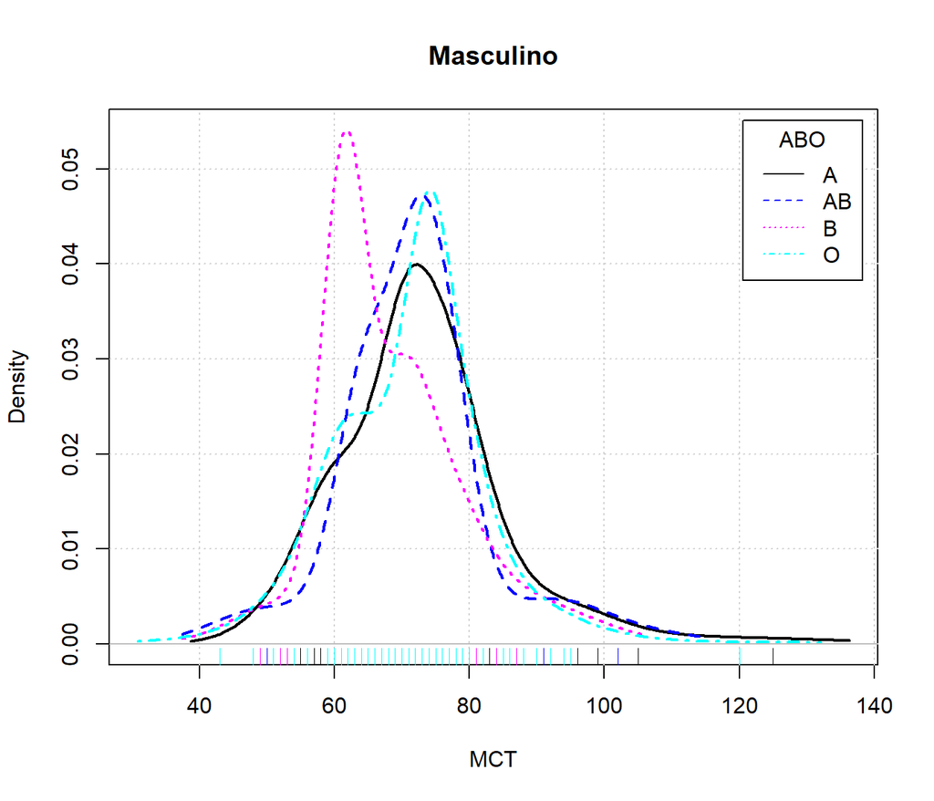

```r
car::densityPlot(MCT~ABO, data=Dados.M,
                 main="Masculino")
```

## Gráfico de distribuição de probabilidade: ECDF plot

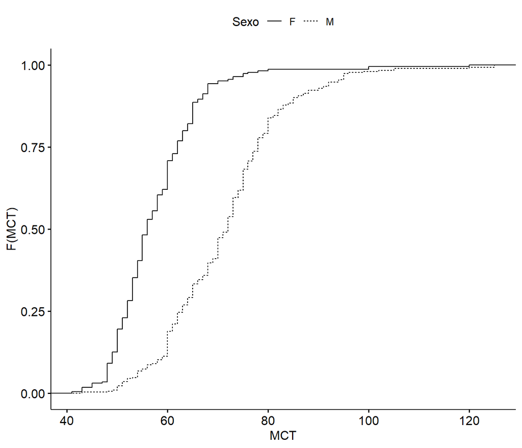

```r
ggpubr::ggecdf(data=Dados,
               x="MCT",
               linetype="Sexo")
```

## Gráfico de dispersão com `sunflowerplot`

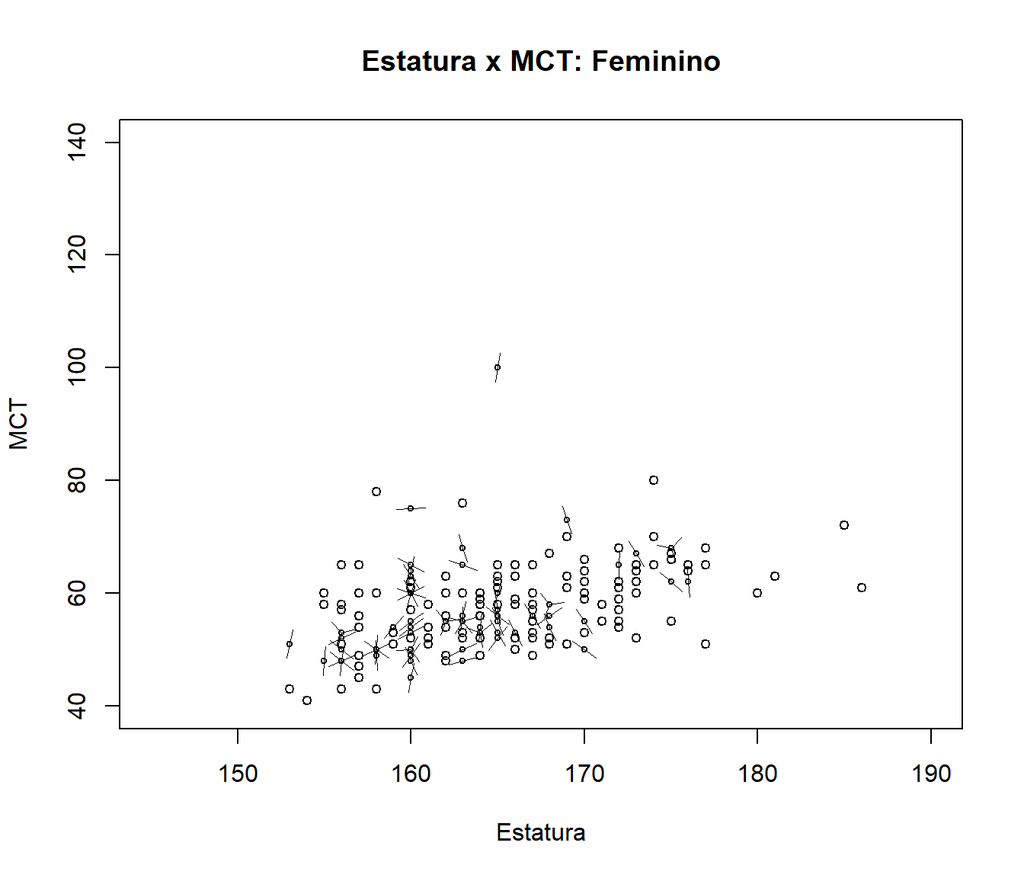

```r
sunflowerplot(MCT~Estatura,
              main="Estatura x MCT: Feminino",
              data=Dados.F,
              rotate=TRUE,
              pch=1,
              size=.1,
              col="black",
              seg.col="black",
              xlim=c(145,190),
              ylim=c(40,140),
              seg.lwd=.8)
```

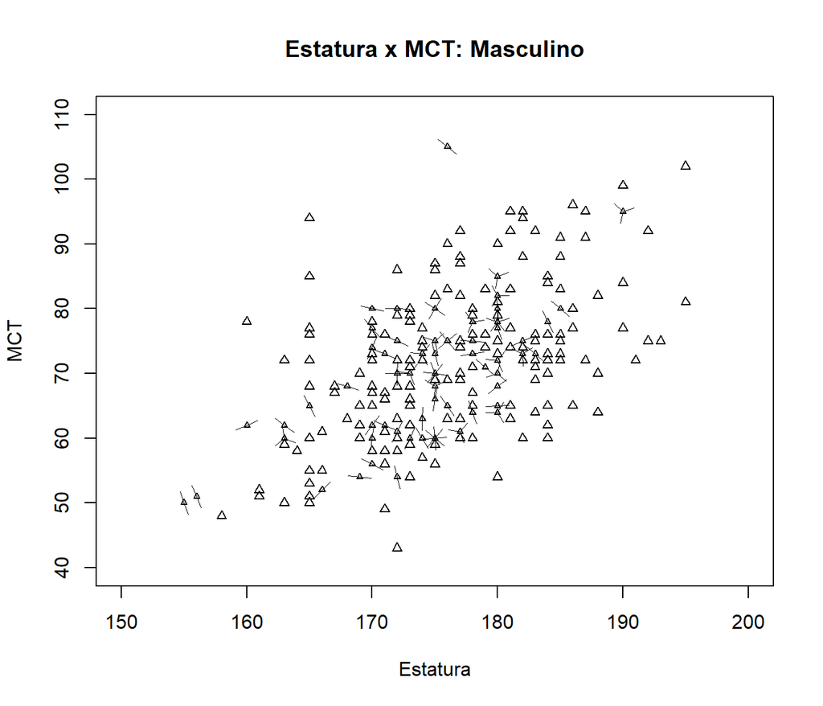

```r
sunflowerplot(MCT~Estatura,
              main="Estatura x MCT: Masculino",
              data=Dados.M,
              rotate=TRUE,
              pch=2,
              size=.1,
              col="black",
              seg.col="black",
              xlim=c(150,200),
              ylim=c(40,110),
              seg.lwd=.8,
              add=FALSE)
```

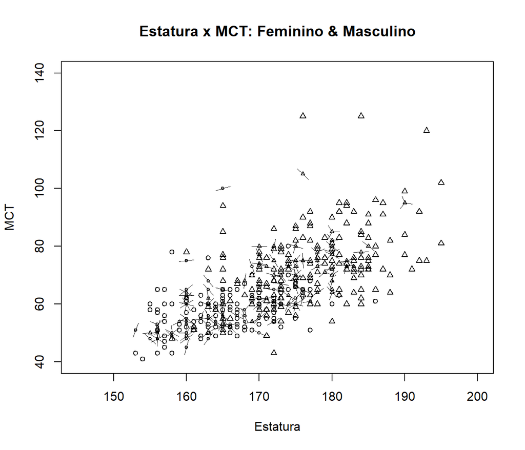

```r
sunflowerplot(MCT~Estatura,
              main="Estatura x MCT: Feminino & Masculino",
              data=Dados.F,
              rotate=TRUE,
              pch=1,
              size=.1,
              col="black",
              seg.col="black",
              xlim=c(145,200),
              ylim=c(40,140),
              seg.lwd=.8)
sunflowerplot(MCT~Estatura,
              data=Dados.M,
              rotate=TRUE,
              pch=2,
              size=.1,
              col="black",
              seg.col="black",
              seg.lwd=.8,
              add=TRUE)
```

## Gráfico de dispersão com `car::scatterplot`

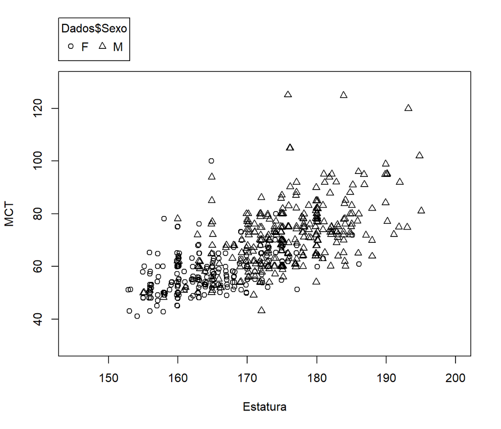

```r
car::scatterplot(MCT~Estatura,
                 group=Dados$Sexo,
                 jitter=list(x=1, y=1),
                 regLine=FALSE,
                 smooth=FALSE,
                 ellipse=FALSE,
                 grid=FALSE,
                 col="black",
                 xlim=c(145,200),
                 ylim=c(30,130),
                 data=Dados)
```

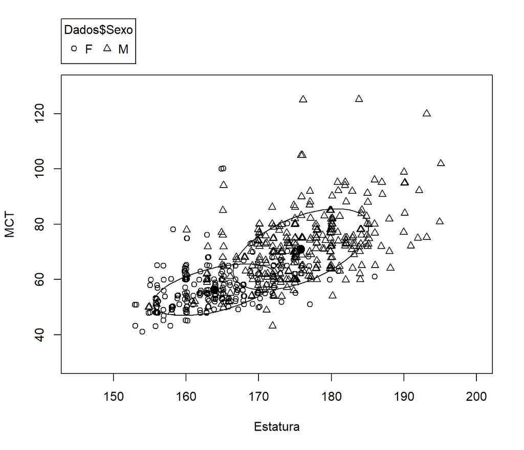

```r
car::scatterplot(MCT~Estatura,
                 group=Dados$Sexo,
                 jitter=list(x=1, y=1),
                 regLine=FALSE,
                 smooth=FALSE,
                 boxplots=TRUE,
                 ellipse=list(levels=c(0.68),
                              robust=TRUE,
                              fill=FALSE,
                              fill.alpha=0.2),
                 grid=FALSE,
                 col="black",
                 xlim=c(145,200),
                 ylim=c(30,130),
                 data=Dados)
```

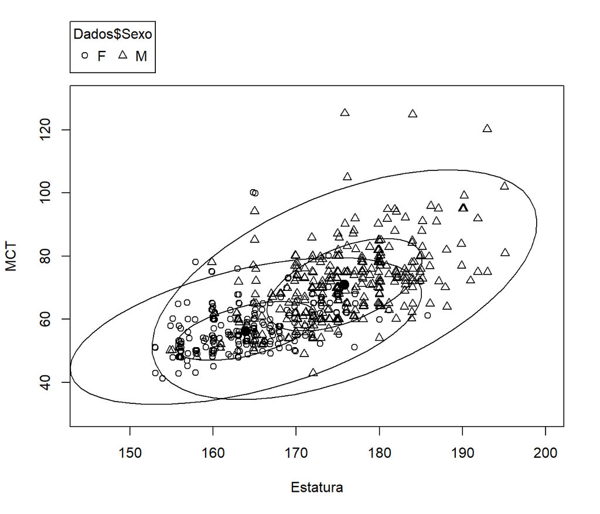

```r
car::scatterplot(MCT~Estatura,
                 group=Dados$Sexo,
                 jitter=list(x=1, y=1),
                 regLine=FALSE,
                 smooth=FALSE,
                 ellipse=list(levels=c(0.68,0.999),
                              robust=TRUE,
                              fill=FALSE,
                              fill.alpha=0.2),
                 grid=FALSE,
                 col="black",
                 xlim=c(145,200),
                 ylim=c(30,130),
                 data=Dados)
```

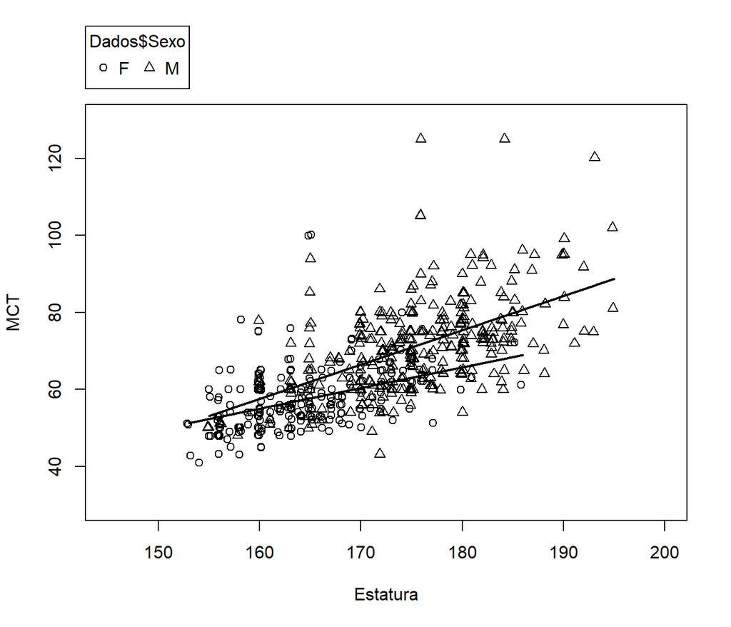

```r
car::scatterplot(MCT~Estatura,
                 group=Dados$Sexo,
                 jitter=list(x=1, y=1),
                 regLine=TRUE,
                 smooth=FALSE,
                 ellipse=FALSE,
                 grid=FALSE,
                 col="black",
                 xlim=c(145,200),
                 ylim=c(30,130),
                 data=Dados)
```

## Gráfico de dispersão matricial

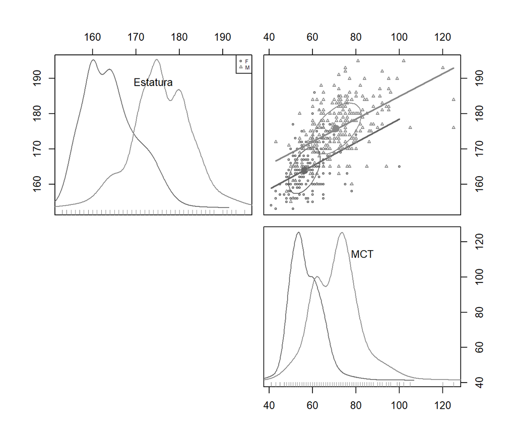

```r
car::scatterplotMatrix(Dados[,c("Estatura",
                                "MCT")],
                       groups=Dados$Sexo,
                       lower.panel=NULL,
                       regLine=TRUE,
                       smooth=FALSE,
                       by.groups=TRUE,
                       ellipse=list(levels=c(0.5),
                                    robust=TRUE,
                                    fill=FALSE),
                       col=c("#666666","#888888","#cccccc"),
                       cex=0.5,
                       cex.labels=1,
                       row1attop=TRUE)
```

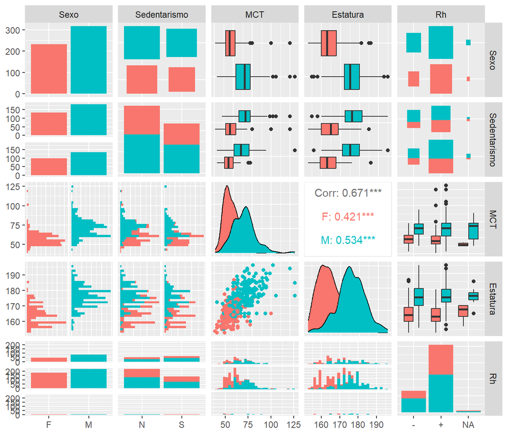

```r
GGally::ggpairs(subset(Dados,
                       select=-c(ID,Ano,Turma,Mao,TipoSang,
                                 ABO,AtivFisica,IMC)),
                ggplot2::aes(colour=Sexo))
```

## Intervalo de confiança: comparação de médias populacionais

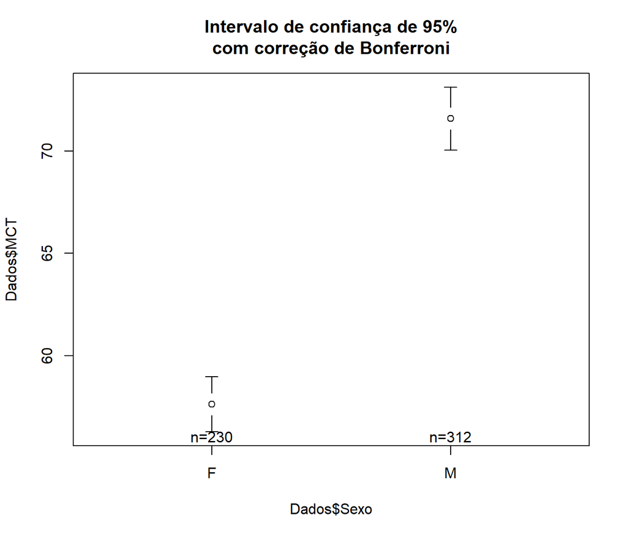

```r
alpha <- 0.05
gplots::plotmeans(Dados$MCT~Dados$Sexo,
                  main="Intervalo de confiança de 95%\ncom correção de Bonferroni",
                  col="black",
                  barcol="black",
                  p=1-alpha/length(unique(levels(Dados$Sexo))),
                  connect=FALSE)
```

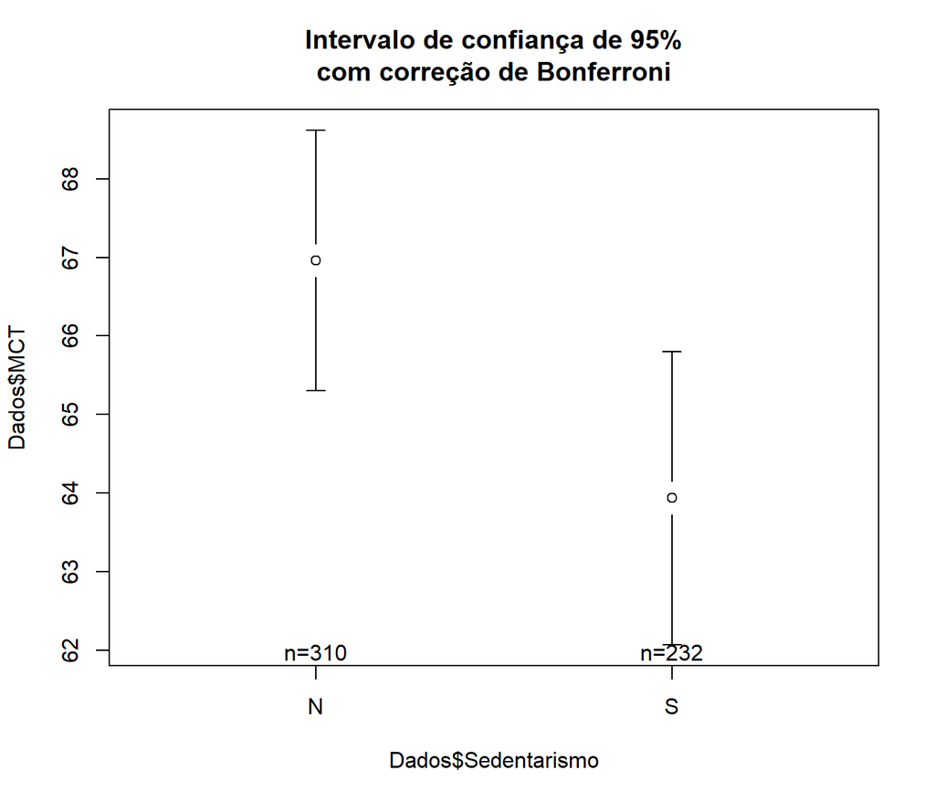

```r
gplots::plotmeans(Dados$MCT~Dados$Sedentarismo,
                  main="Intervalo de confiança de 95%\ncom correção de Bonferroni",
                  col="black",
                  barcol="black",
                  p=1-alpha/length(unique(levels(Dados$Sexo))),
                  connect=FALSE)
```

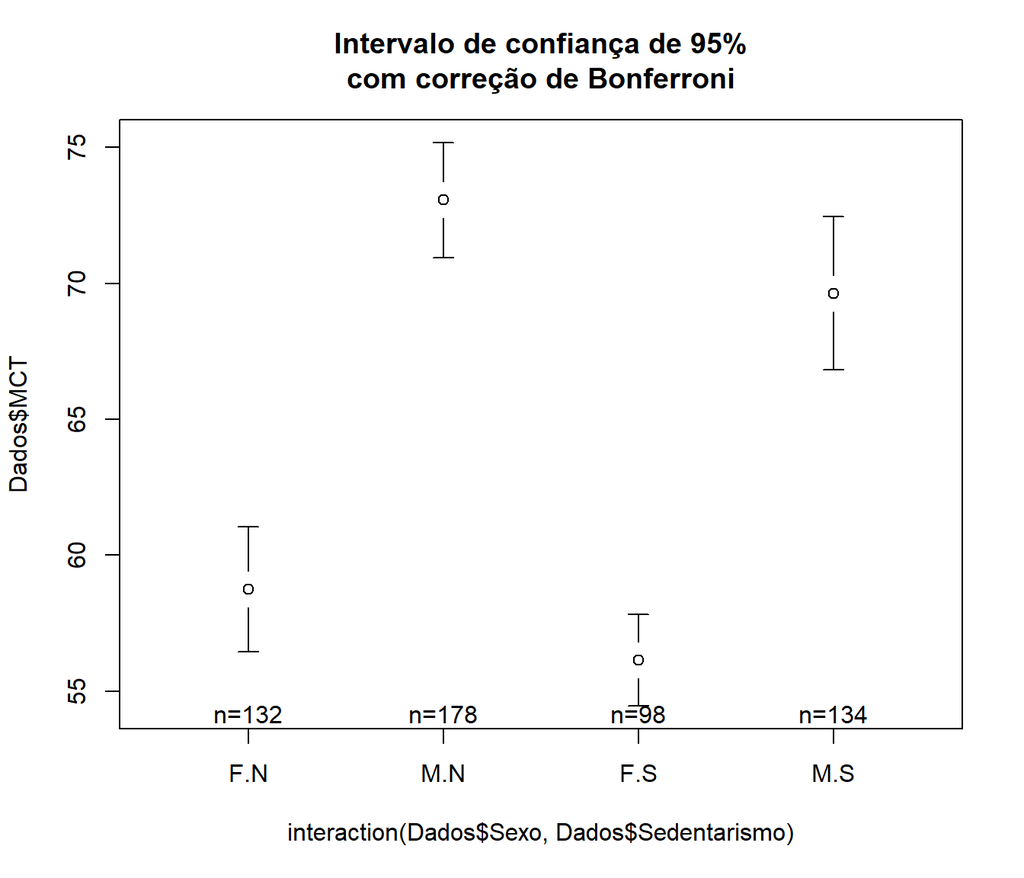

```r
gplots::plotmeans(Dados$MCT~ interaction(Dados$Sexo,
                                         Dados$Sedentarismo),
                  main="Intervalo de confiança de 95%\ncom correção de Bonferroni",
                  col="black",
                  barcol="black",
                  p=1-alpha/(length(unique(levels(Dados$Sexo)))*
                    length(unique(levels(Dados$Sedentarismo)))),
                  connect=FALSE)
```

## Gráficos avançados

- ggplot2
  - https://ggplot2.tidyverse.org/
- Módulo V: Gráficos com ggplot2 por Bruno Lucian & Claudia Jakelline
  - https://bookdown.org/bruno_lucian_costa/CursoBasicoR/m5.html#gr%C3%A1ficos-com-ggplot2
- ggplot2 - Essentials
  - http://www.sthda.com/english/wiki/ggplot2-essentials
- The R Graph Gallery
  - https://r-graph-gallery.com/index.html
- Advanced plotting by Jeff Powell and Remko Duursma
  - http://www.hiercourse.com/advancedplot
  - http://www.hiercourse.com/docs/advanced_plotting.html
- Chapter 19. Advanced graphics with ggplot2
  - https://livebook.manning.com/book/r-in-action-second-edition/chapter-19/1
- Top 50 ggplot2 Visualizations - The Master List (With Full R Code)
  - http://r-statistics.co/Top50-Ggplot2-Visualizations-MasterList-R-Code.html

# Ler arquivo de dados com medidas repetidas

## Ler e transformar a estrutura de dados de wide para long

- `NewDrug.xls`
  - Fonte dos dados: Norusis, M (2021) *IBM SPSS Statistics 19 Statistical Procedures Companion*. Chapter: GLM Repeated Measures. USA: Addison Wesley.

Este arquivo tem 12 pacientes, em dois grupos (nova droga e placebo), dada um deles com três medidas de `resp` e três de `pulse`.

```r
Dados.wide <- readxl::read_xlsx("NewDrug.xlsx")
Dados.wide$drug <- factor(Dados.wide$drug)
knitr::kable(Dados.wide, format="html", caption="New Drug: wide")
```

New Drug: wide

| drug | resp1 | resp2 | resp3 | pulse1 | pulse2 | pulse3 |
| --- | --- | --- | --- | --- | --- | --- |
| New Drug | 3.4 | 3.3 | 3.3 | 2.2 | 2.1 | 2.1 |
| New Drug | 3.4 | 3.4 | 3.3 | 2.2 | 2.1 | 2.2 |
| New Drug | 3.3 | 3.4 | 3.4 | 2.3 | 2.4 | 2.3 |
| New Drug | 3.4 | 3.4 | 3.4 | 2.3 | 2.4 | 2.3 |
| New Drug | 3.3 | 3.4 | 3.3 | 2.2 | 2.2 | 2.4 |
| New Drug | 3.3 | 3.3 | 3.3 | 2.0 | 2.1 | 2.4 |
| Placebo | 3.3 | 3.3 | 3.3 | 2.8 | 2.9 | 2.7 |
| Placebo | 3.2 | 3.3 | 3.4 | 2.6 | 2.7 | 2.7 |
| Placebo | 3.2 | 3.2 | 3.2 | 2.7 | 2.9 | 2.7 |
| Placebo | 3.2 | 3.2 | 3.2 | 2.6 | 2.8 | 2.9 |
| Placebo | 3.2 | 3.3 | 3.3 | 2.7 | 2.8 | 2.9 |
| Placebo | 3.3 | 3.2 | 3.1 | 2.6 | 2.8 | 2.8 |

```r
print(psych::describeBy(subset(Dados.wide,select=c(-drug)),
                    group=list(Dados.wide$drug),
                    mat=TRUE,
                    digits=2))
```

```
        item   group1 vars n mean   sd median trimmed  mad min max range  skew
resp11     1 New Drug    1 6 3.35 0.05   3.35    3.35 0.07 3.3 3.4   0.1  0.00
resp12     2  Placebo    1 6 3.23 0.05   3.20    3.23 0.00 3.2 3.3   0.1  0.54
resp21     3 New Drug    2 6 3.37 0.05   3.40    3.37 0.00 3.3 3.4   0.1 -0.54
resp22     4  Placebo    2 6 3.25 0.05   3.25    3.25 0.07 3.2 3.3   0.1  0.00
resp31     5 New Drug    3 6 3.33 0.05   3.30    3.33 0.00 3.3 3.4   0.1  0.54
resp32     6  Placebo    3 6 3.25 0.10   3.25    3.25 0.07 3.1 3.4   0.3  0.00
pulse11    7 New Drug    4 6 2.20 0.11   2.20    2.20 0.07 2.0 2.3   0.3 -0.76
pulse12    8  Placebo    4 6 2.67 0.08   2.65    2.67 0.07 2.6 2.8   0.2  0.48
pulse21    9 New Drug    5 6 2.22 0.15   2.15    2.22 0.07 2.1 2.4   0.3  0.39
pulse22   10  Placebo    5 6 2.82 0.08   2.80    2.82 0.07 2.7 2.9   0.2 -0.17
pulse31   11 New Drug    6 6 2.28 0.12   2.30    2.28 0.15 2.1 2.4   0.3 -0.37
pulse32   12  Placebo    6 6 2.78 0.10   2.75    2.78 0.07 2.7 2.9   0.2  0.25
        kurtosis   se
resp11     -2.31 0.02
resp12     -1.96 0.02
resp21     -1.96 0.02
resp22     -2.31 0.02
resp31     -1.96 0.02
resp32     -1.57 0.04
pulse11    -0.92 0.04
pulse12    -1.58 0.03
pulse21    -2.00 0.06
pulse22    -1.54 0.03
pulse31    -1.62 0.05
pulse32    -2.08 0.04
```

```r
str(Dados.wide)
```

```
tibble [12 × 7] (S3: tbl_df/tbl/data.frame)
 $ drug  : Factor w/ 2 levels "New Drug","Placebo": 1 1 1 1 1 1 2 2 2 2 ...
 $ resp1 : num [1:12] 3.4 3.4 3.3 3.4 3.3 3.3 3.3 3.2 3.2 3.2 ...
 $ resp2 : num [1:12] 3.3 3.4 3.4 3.4 3.4 3.3 3.3 3.3 3.2 3.2 ...
 $ resp3 : num [1:12] 3.3 3.3 3.4 3.4 3.3 3.3 3.3 3.4 3.2 3.2 ...
 $ pulse1: num [1:12] 2.2 2.2 2.3 2.3 2.2 2 2.8 2.6 2.7 2.6 ...
 $ pulse2: num [1:12] 2.1 2.1 2.4 2.4 2.2 2.1 2.9 2.7 2.9 2.8 ...
 $ pulse3: num [1:12] 2.1 2.2 2.3 2.3 2.4 2.4 2.7 2.7 2.7 2.9 ...
```

```r
labelled::look_for(Dados.wide)
```

```
# A tibble: 7 × 7
    pos variable label col_type missing levels       value_labels
  <int> <chr>    <chr> <chr>      <int> <named list> <named list>
1     1 drug     <NA>  fct            0 <chr [2]>    <NULL>
2     2 resp1    <NA>  dbl            0 <NULL>       <NULL>
3     3 resp2    <NA>  dbl            0 <NULL>       <NULL>
4     4 resp3    <NA>  dbl            0 <NULL>       <NULL>
5     5 pulse1   <NA>  dbl            0 <NULL>       <NULL>
6     6 pulse2   <NA>  dbl            0 <NULL>       <NULL>
7     7 pulse3   <NA>  dbl            0 <NULL>       <NULL>
```

```r
Dados.wide <- cbind(seq(1:nrow(Dados.wide)),Dados.wide)
names(Dados.wide) <- c("ID",names(Dados.wide[,2:ncol(Dados.wide)]))
labelled::look_for(Dados.wide)
```

```
# A tibble: 8 × 7
    pos variable label col_type missing levels       value_labels
  <int> <chr>    <chr> <chr>      <int> <named list> <named list>
1     1 ID       <NA>  int            0 <NULL>       <NULL>
2     2 drug     <NA>  fct            0 <chr [2]>    <NULL>
3     3 resp1    <NA>  dbl            0 <NULL>       <NULL>
4     4 resp2    <NA>  dbl            0 <NULL>       <NULL>
5     5 resp3    <NA>  dbl            0 <NULL>       <NULL>
6     6 pulse1   <NA>  dbl            0 <NULL>       <NULL>
7     7 pulse2   <NA>  dbl            0 <NULL>       <NULL>
8     8 pulse3   <NA>  dbl            0 <NULL>       <NULL>
```

```r
Dados.long <- Hmisc::reShape(Dados.wide,
                             id=c("ID"),
                             colvar=c("drug"),
                             base=c("resp", "pulse"),
                             reps=3,
                             timevar="time",
                             times=c(1,2,3))
str(Dados.long)
```

```
'data.frame':   36 obs. of  5 variables:
 $ time : num  1 2 3 1 2 3 1 2 3 1 ...
 $ ID   : int  1 1 1 2 2 2 3 3 3 4 ...
 $ drug : Factor w/ 2 levels "New Drug","Placebo": 1 1 1 1 1 1 1 1 1 1 ...
 $ resp : num  3.4 3.3 3.3 3.4 3.4 3.3 3.3 3.4 3.4 3.4 ...
 $ pulse: num  2.2 2.1 2.1 2.2 2.1 2.2 2.3 2.4 2.3 2.3 ...
```

```r
knitr::kable(Dados.long, format="html", caption="New Drug: long")
```

New Drug: long

|  | time | ID | drug | resp | pulse |
| --- | --- | --- | --- | --- | --- |
| 1 1 | 1 | 1 | New Drug | 3.4 | 2.2 |
| 1 2 | 2 | 1 | New Drug | 3.3 | 2.1 |
| 1 3 | 3 | 1 | New Drug | 3.3 | 2.1 |
| 2 1 | 1 | 2 | New Drug | 3.4 | 2.2 |
| 2 2 | 2 | 2 | New Drug | 3.4 | 2.1 |
| 2 3 | 3 | 2 | New Drug | 3.3 | 2.2 |
| 3 1 | 1 | 3 | New Drug | 3.3 | 2.3 |
| 3 2 | 2 | 3 | New Drug | 3.4 | 2.4 |
| 3 3 | 3 | 3 | New Drug | 3.4 | 2.3 |
| 4 1 | 1 | 4 | New Drug | 3.4 | 2.3 |
| 4 2 | 2 | 4 | New Drug | 3.4 | 2.4 |
| 4 3 | 3 | 4 | New Drug | 3.4 | 2.3 |
| 5 1 | 1 | 5 | New Drug | 3.3 | 2.2 |
| 5 2 | 2 | 5 | New Drug | 3.4 | 2.2 |
| 5 3 | 3 | 5 | New Drug | 3.3 | 2.4 |
| 6 1 | 1 | 6 | New Drug | 3.3 | 2.0 |
| 6 2 | 2 | 6 | New Drug | 3.3 | 2.1 |
| 6 3 | 3 | 6 | New Drug | 3.3 | 2.4 |
| 7 1 | 1 | 7 | Placebo | 3.3 | 2.8 |
| 7 2 | 2 | 7 | Placebo | 3.3 | 2.9 |
| 7 3 | 3 | 7 | Placebo | 3.3 | 2.7 |
| 8 1 | 1 | 8 | Placebo | 3.2 | 2.6 |
| 8 2 | 2 | 8 | Placebo | 3.3 | 2.7 |
| 8 3 | 3 | 8 | Placebo | 3.4 | 2.7 |
| 9 1 | 1 | 9 | Placebo | 3.2 | 2.7 |
| 9 2 | 2 | 9 | Placebo | 3.2 | 2.9 |
| 9 3 | 3 | 9 | Placebo | 3.2 | 2.7 |
| 10 1 | 1 | 10 | Placebo | 3.2 | 2.6 |
| 10 2 | 2 | 10 | Placebo | 3.2 | 2.8 |
| 10 3 | 3 | 10 | Placebo | 3.2 | 2.9 |
| 11 1 | 1 | 11 | Placebo | 3.2 | 2.7 |
| 11 2 | 2 | 11 | Placebo | 3.3 | 2.8 |
| 11 3 | 3 | 11 | Placebo | 3.3 | 2.9 |
| 12 1 | 1 | 12 | Placebo | 3.3 | 2.6 |
| 12 2 | 2 | 12 | Placebo | 3.2 | 2.8 |
| 12 3 | 3 | 12 | Placebo | 3.1 | 2.8 |

```r
rownames((Dados.long))
```

```
 [1] "1 1"  "1 2"  "1 3"  "2 1"  "2 2"  "2 3"  "3 1"  "3 2"  "3 3"  "4 1"
[11] "4 2"  "4 3"  "5 1"  "5 2"  "5 3"  "6 1"  "6 2"  "6 3"  "7 1"  "7 2"
[21] "7 3"  "8 1"  "8 2"  "8 3"  "9 1"  "9 2"  "9 3"  "10 1" "10 2" "10 3"
[31] "11 1" "11 2" "11 3" "12 1" "12 2" "12 3"
```

```r
Dados.lista <- list(Dados.wide, Dados.long)
names(Dados.lista) <- c("NewDrug_wide", "NewDrug_long")
saveRDS(Dados.lista, "NewDrug_wide_long.rds")
Dados_wide_long <- readRDS("NewDrug_wide_long.rds")
str(Dados_wide_long)
```

```
List of 2
 $ NewDrug_wide:'data.frame':   12 obs. of  8 variables:
  ..$ ID    : int [1:12] 1 2 3 4 5 6 7 8 9 10 ...
  ..$ drug  : Factor w/ 2 levels "New Drug","Placebo": 1 1 1 1 1 1 2 2 2 2 ...
  ..$ resp1 : num [1:12] 3.4 3.4 3.3 3.4 3.3 3.3 3.3 3.2 3.2 3.2 ...
  ..$ resp2 : num [1:12] 3.3 3.4 3.4 3.4 3.4 3.3 3.3 3.3 3.2 3.2 ...
  ..$ resp3 : num [1:12] 3.3 3.3 3.4 3.4 3.3 3.3 3.3 3.4 3.2 3.2 ...
  ..$ pulse1: num [1:12] 2.2 2.2 2.3 2.3 2.2 2 2.8 2.6 2.7 2.6 ...
  ..$ pulse2: num [1:12] 2.1 2.1 2.4 2.4 2.2 2.1 2.9 2.7 2.9 2.8 ...
  ..$ pulse3: num [1:12] 2.1 2.2 2.3 2.3 2.4 2.4 2.7 2.7 2.7 2.9 ...
 $ NewDrug_long:'data.frame':   36 obs. of  5 variables:
  ..$ time : num [1:36] 1 2 3 1 2 3 1 2 3 1 ...
  ..$ ID   : int [1:36] 1 1 1 2 2 2 3 3 3 4 ...
  ..$ drug : Factor w/ 2 levels "New Drug","Placebo": 1 1 1 1 1 1 1 1 1 1 ...
  ..$ resp : num [1:36] 3.4 3.3 3.3 3.4 3.4 3.3 3.3 3.4 3.4 3.4 ...
  ..$ pulse: num [1:36] 2.2 2.1 2.1 2.2 2.1 2.2 2.3 2.4 2.3 2.3 ...
```

```r
knitr::kable(Dados_wide_long$NewDrug_wide, format="html", caption="New Drug: wide")
```

New Drug: wide

| ID | drug | resp1 | resp2 | resp3 | pulse1 | pulse2 | pulse3 |
| --- | --- | --- | --- | --- | --- | --- | --- |
| 1 | New Drug | 3.4 | 3.3 | 3.3 | 2.2 | 2.1 | 2.1 |
| 2 | New Drug | 3.4 | 3.4 | 3.3 | 2.2 | 2.1 | 2.2 |
| 3 | New Drug | 3.3 | 3.4 | 3.4 | 2.3 | 2.4 | 2.3 |
| 4 | New Drug | 3.4 | 3.4 | 3.4 | 2.3 | 2.4 | 2.3 |
| 5 | New Drug | 3.3 | 3.4 | 3.3 | 2.2 | 2.2 | 2.4 |
| 6 | New Drug | 3.3 | 3.3 | 3.3 | 2.0 | 2.1 | 2.4 |
| 7 | Placebo | 3.3 | 3.3 | 3.3 | 2.8 | 2.9 | 2.7 |
| 8 | Placebo | 3.2 | 3.3 | 3.4 | 2.6 | 2.7 | 2.7 |
| 9 | Placebo | 3.2 | 3.2 | 3.2 | 2.7 | 2.9 | 2.7 |
| 10 | Placebo | 3.2 | 3.2 | 3.2 | 2.6 | 2.8 | 2.9 |
| 11 | Placebo | 3.2 | 3.3 | 3.3 | 2.7 | 2.8 | 2.9 |
| 12 | Placebo | 3.3 | 3.2 | 3.1 | 2.6 | 2.8 | 2.8 |

```r
knitr::kable(Dados_wide_long$NewDrug_long, format="html", caption="New Drug: long")
```

New Drug: long

|  | time | ID | drug | resp | pulse |
| --- | --- | --- | --- | --- | --- |
| 1 1 | 1 | 1 | New Drug | 3.4 | 2.2 |
| 1 2 | 2 | 1 | New Drug | 3.3 | 2.1 |
| 1 3 | 3 | 1 | New Drug | 3.3 | 2.1 |
| 2 1 | 1 | 2 | New Drug | 3.4 | 2.2 |
| 2 2 | 2 | 2 | New Drug | 3.4 | 2.1 |
| 2 3 | 3 | 2 | New Drug | 3.3 | 2.2 |
| 3 1 | 1 | 3 | New Drug | 3.3 | 2.3 |
| 3 2 | 2 | 3 | New Drug | 3.4 | 2.4 |
| 3 3 | 3 | 3 | New Drug | 3.4 | 2.3 |
| 4 1 | 1 | 4 | New Drug | 3.4 | 2.3 |
| 4 2 | 2 | 4 | New Drug | 3.4 | 2.4 |
| 4 3 | 3 | 4 | New Drug | 3.4 | 2.3 |
| 5 1 | 1 | 5 | New Drug | 3.3 | 2.2 |
| 5 2 | 2 | 5 | New Drug | 3.4 | 2.2 |
| 5 3 | 3 | 5 | New Drug | 3.3 | 2.4 |
| 6 1 | 1 | 6 | New Drug | 3.3 | 2.0 |
| 6 2 | 2 | 6 | New Drug | 3.3 | 2.1 |
| 6 3 | 3 | 6 | New Drug | 3.3 | 2.4 |
| 7 1 | 1 | 7 | Placebo | 3.3 | 2.8 |
| 7 2 | 2 | 7 | Placebo | 3.3 | 2.9 |
| 7 3 | 3 | 7 | Placebo | 3.3 | 2.7 |
| 8 1 | 1 | 8 | Placebo | 3.2 | 2.6 |
| 8 2 | 2 | 8 | Placebo | 3.3 | 2.7 |
| 8 3 | 3 | 8 | Placebo | 3.4 | 2.7 |
| 9 1 | 1 | 9 | Placebo | 3.2 | 2.7 |
| 9 2 | 2 | 9 | Placebo | 3.2 | 2.9 |
| 9 3 | 3 | 9 | Placebo | 3.2 | 2.7 |
| 10 1 | 1 | 10 | Placebo | 3.2 | 2.6 |
| 10 2 | 2 | 10 | Placebo | 3.2 | 2.8 |
| 10 3 | 3 | 10 | Placebo | 3.2 | 2.9 |
| 11 1 | 1 | 11 | Placebo | 3.2 | 2.7 |
| 11 2 | 2 | 11 | Placebo | 3.3 | 2.8 |
| 11 3 | 3 | 11 | Placebo | 3.3 | 2.9 |
| 12 1 | 1 | 12 | Placebo | 3.3 | 2.6 |
| 12 2 | 2 | 12 | Placebo | 3.2 | 2.8 |
| 12 3 | 3 | 12 | Placebo | 3.1 | 2.8 |

## Ler e transformar a estrutura de dados de long para wide

```r
Dados.wide.resp <- reshape2::dcast(Dados.long,
                                   ID + drug ~ time,
                                   value.var="resp")
names(Dados.wide.resp) <- c("ID","drug","resp1","resp2","resp3")
knitr::kable(Dados.wide.resp, format="html", caption="New Drug: resp wide")
```

New Drug: resp wide

| ID | drug | resp1 | resp2 | resp3 |
| --- | --- | --- | --- | --- |
| 1 | New Drug | 3.4 | 3.3 | 3.3 |
| 2 | New Drug | 3.4 | 3.4 | 3.3 |
| 3 | New Drug | 3.3 | 3.4 | 3.4 |
| 4 | New Drug | 3.4 | 3.4 | 3.4 |
| 5 | New Drug | 3.3 | 3.4 | 3.3 |
| 6 | New Drug | 3.3 | 3.3 | 3.3 |
| 7 | Placebo | 3.3 | 3.3 | 3.3 |
| 8 | Placebo | 3.2 | 3.3 | 3.4 |
| 9 | Placebo | 3.2 | 3.2 | 3.2 |
| 10 | Placebo | 3.2 | 3.2 | 3.2 |
| 11 | Placebo | 3.2 | 3.3 | 3.3 |
| 12 | Placebo | 3.3 | 3.2 | 3.1 |

```r
Dados.wide.pulse <- reshape2::dcast(Dados.long,
                                    ID + drug ~ time,
                                    value.var="pulse")
names(Dados.wide.pulse) <- c("ID","drug","pulse1","pulse2","pulse3")
knitr::kable(Dados.wide.pulse, format="html", caption="New Drug: pulse wide")
```

New Drug: pulse wide

| ID | drug | pulse1 | pulse2 | pulse3 |
| --- | --- | --- | --- | --- |
| 1 | New Drug | 2.2 | 2.1 | 2.1 |
| 2 | New Drug | 2.2 | 2.1 | 2.2 |
| 3 | New Drug | 2.3 | 2.4 | 2.3 |
| 4 | New Drug | 2.3 | 2.4 | 2.3 |
| 5 | New Drug | 2.2 | 2.2 | 2.4 |
| 6 | New Drug | 2.0 | 2.1 | 2.4 |
| 7 | Placebo | 2.8 | 2.9 | 2.7 |
| 8 | Placebo | 2.6 | 2.7 | 2.7 |
| 9 | Placebo | 2.7 | 2.9 | 2.7 |
| 10 | Placebo | 2.6 | 2.8 | 2.9 |
| 11 | Placebo | 2.7 | 2.8 | 2.9 |
| 12 | Placebo | 2.6 | 2.8 | 2.8 |

```r
Dados.wide <- cbind(Dados.wide.resp,
                    Dados.wide.pulse[c("pulse1","pulse2","pulse3")])
knitr::kable(Dados.wide, format="html", caption="New Drug: wide")
```

New Drug: wide

| ID | drug | resp1 | resp2 | resp3 | pulse1 | pulse2 | pulse3 |
| --- | --- | --- | --- | --- | --- | --- | --- |
| 1 | New Drug | 3.4 | 3.3 | 3.3 | 2.2 | 2.1 | 2.1 |
| 2 | New Drug | 3.4 | 3.4 | 3.3 | 2.2 | 2.1 | 2.2 |
| 3 | New Drug | 3.3 | 3.4 | 3.4 | 2.3 | 2.4 | 2.3 |
| 4 | New Drug | 3.4 | 3.4 | 3.4 | 2.3 | 2.4 | 2.3 |
| 5 | New Drug | 3.3 | 3.4 | 3.3 | 2.2 | 2.2 | 2.4 |
| 6 | New Drug | 3.3 | 3.3 | 3.3 | 2.0 | 2.1 | 2.4 |
| 7 | Placebo | 3.3 | 3.3 | 3.3 | 2.8 | 2.9 | 2.7 |
| 8 | Placebo | 3.2 | 3.3 | 3.4 | 2.6 | 2.7 | 2.7 |
| 9 | Placebo | 3.2 | 3.2 | 3.2 | 2.7 | 2.9 | 2.7 |
| 10 | Placebo | 3.2 | 3.2 | 3.2 | 2.6 | 2.8 | 2.9 |
| 11 | Placebo | 3.2 | 3.3 | 3.3 | 2.7 | 2.8 | 2.9 |
| 12 | Placebo | 3.3 | 3.2 | 3.1 | 2.6 | 2.8 | 2.8 |

# Ler dados dentro do script R

```r
# https://rcompanion.org

Dados <- read.table(header=TRUE,
                    stringsAsFactors=TRUE,
                    text="
 Medico   Conceito
 A        3
 A        5
 A        4
 A        4
 A        4
 A        4
 A        4
 A        4
 A        5
 A        5
 B        2
 B        4
 B        2
 B        2
 B        1
 B        2
 B        3
 B        2
 B        2
 B        3
")
Dados$Conceito <- factor(Dados$Conceito, ordered=TRUE)
levels(Dados$Conceito)
```

```
[1] "1" "2" "3" "4" "5"
```

```r
class(Dados)
```

```
[1] "data.frame"
```

```r
str(Dados)
```

```
'data.frame':   20 obs. of  2 variables:
 $ Medico  : Factor w/ 2 levels "A","B": 1 1 1 1 1 1 1 1 1 1 ...
 $ Conceito: Ord.factor w/ 5 levels "1"<"2"<"3"<"4"<..: 3 5 4 4 4 4 4 4 5 5 ...
```

```r
knitr::kable(Dados, format="html", caption="Médico: conceito")
```

Médico: conceito

| Medico | Conceito |
| --- | --- |
| A | 3 |
| A | 5 |
| A | 4 |
| A | 4 |
| A | 4 |
| A | 4 |
| A | 4 |
| A | 4 |
| A | 5 |
| A | 5 |
| B | 2 |
| B | 4 |
| B | 2 |
| B | 2 |
| B | 1 |
| B | 2 |
| B | 3 |
| B | 2 |
| B | 2 |
| B | 3 |

```r
summary(Dados)
```

```
 Medico Conceito
 A:10   1:1
 B:10   2:6
        3:3
        4:7
        5:3
```

```r
FSA::Summarize(as.numeric(Conceito) ~ Medico,
               digits=3,
               data=Dados)
```

```
# A tibble: 2 × 9
  Medico     n  mean    sd   min    Q1 median    Q3   max
  <fct>  <dbl> <dbl> <dbl> <dbl> <dbl>  <dbl> <dbl> <dbl>
1 A         10   4.2 0.632     3     4      4  4.75     5
2 B         10   2.3 0.823     1     2      2  2.75     4
```

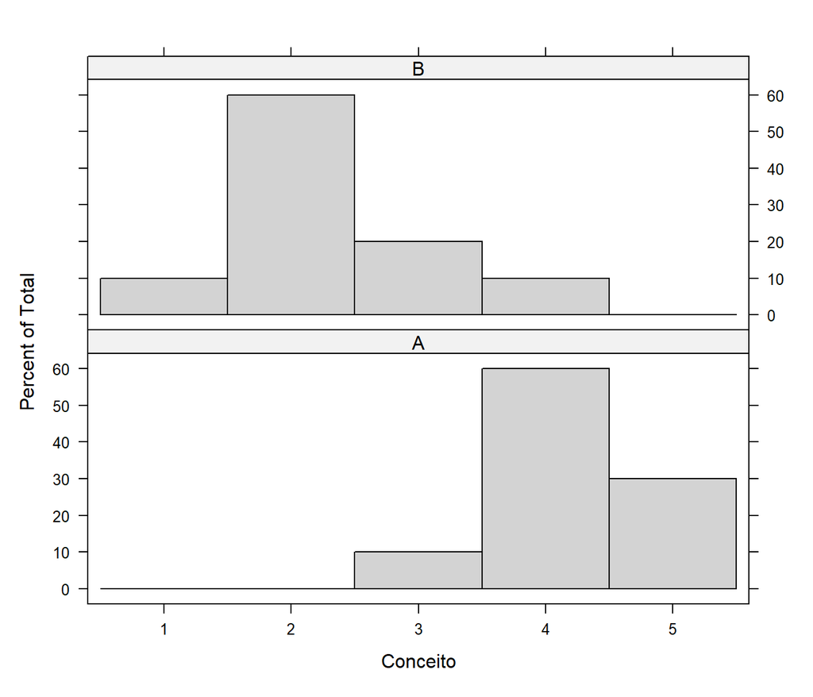

```r
lattice::histogram(~ Conceito | Medico,
                   data=Dados,
                   aspect="fill",
                   col="lightgray",
                   layout=c(1,2))
```

```r
tabela <- xtabs(~ Medico + Conceito, data=Dados)
addmargins(tabela)
```

```
      Conceito
Medico  1  2  3  4  5 Sum
   A    0  0  1  6  3  10
   B    1  6  2  1  0  10
   Sum  1  6  3  7  3  20
```

```r
round(prop.table(tabela, margin=1), 2)
```

```
      Conceito
Medico   1   2   3   4   5
     A 0.0 0.0 0.1 0.6 0.3
     B 0.1 0.6 0.2 0.1 0.0
```

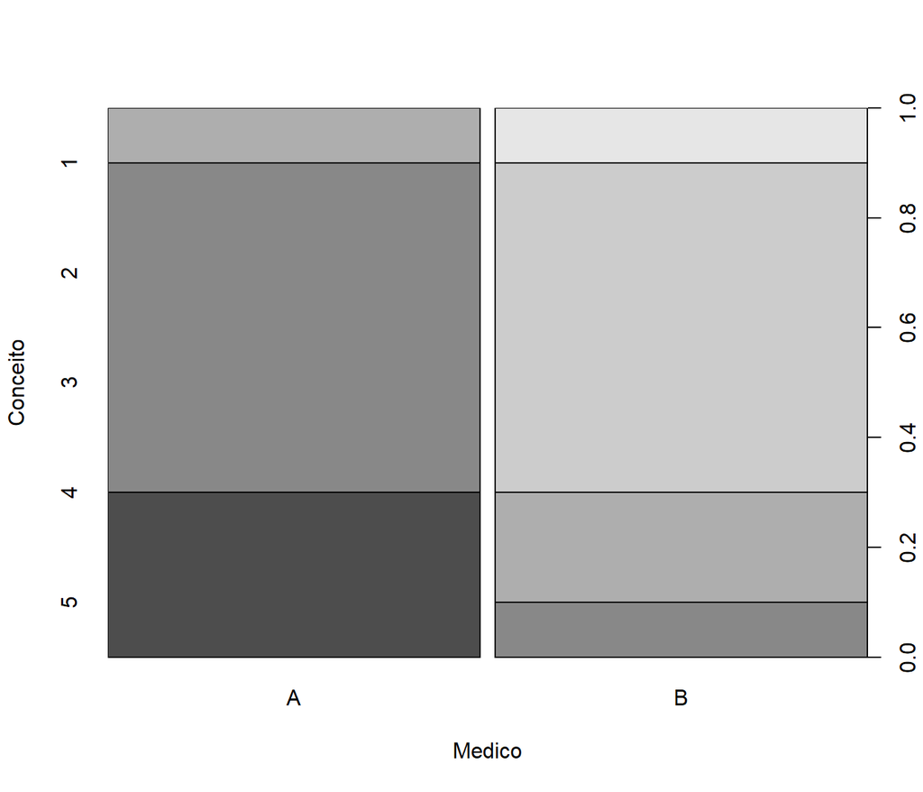

```r
spineplot(tabela)
```

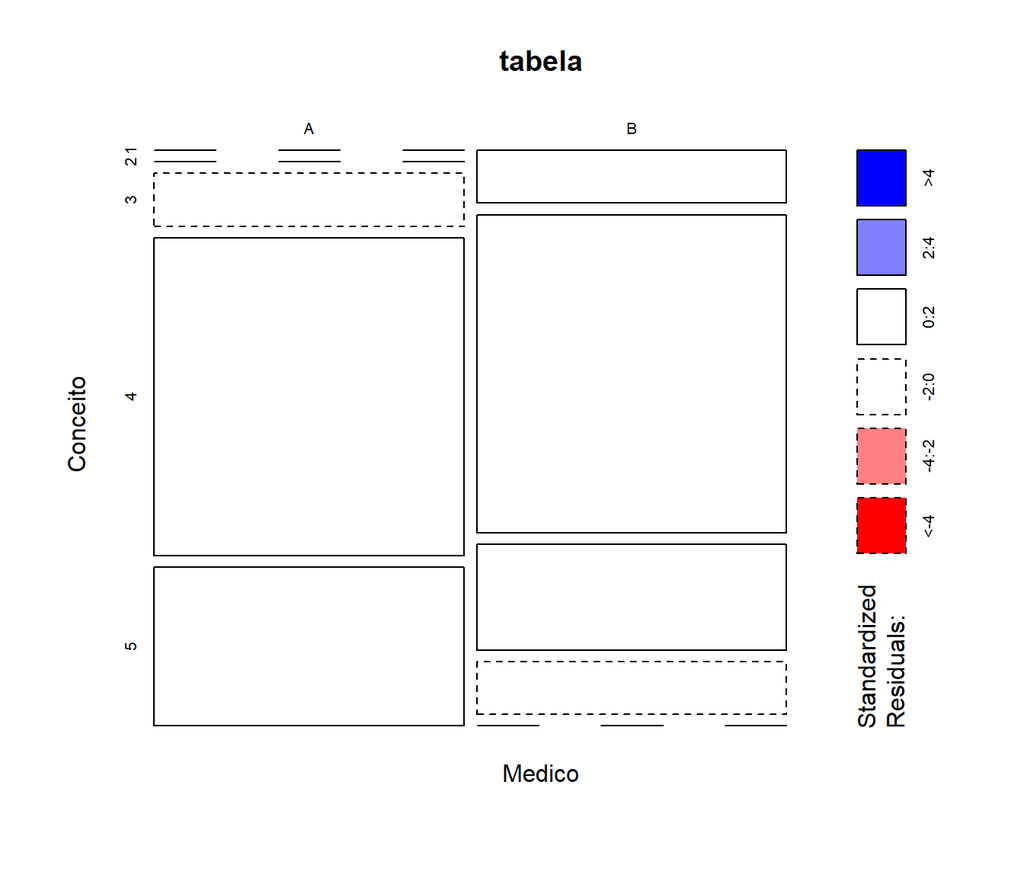

```r
mosaicplot(tabela, shade=TRUE)
```

```r
saveRDS(object=Dados, file="MediConceito.rds")
rm(Dados)
Dados <- readRDS(file="MediConceito.rds")
class(Dados)
```

```
[1] "data.frame"
```

```r
str(Dados)
```

```
'data.frame':   20 obs. of  2 variables:
 $ Medico  : Factor w/ 2 levels "A","B": 1 1 1 1 1 1 1 1 1 1 ...
 $ Conceito: Ord.factor w/ 5 levels "1"<"2"<"3"<"4"<..: 3 5 4 4 4 4 4 4 5 5 ...
```

```r
# Para este exemplo hipotético, os agricultores foram pesquisados sobre com que frequência eles utilizam uma determinada prática de manejo adequado. As respostas são organizadas de acordo com o tamanho da operação. Ambas as variáveis na tabela de contingência são categorias ordenadas.

tabela <- ("
                     Sempre 'AsVezes' Nunca
   Hobbista          0       1         5
   'Pequeno negócio' 2       3         4
   Pequeno           4       4         4
   Médio             3       2         0
   Grande            2       0         0
")

Dados.tabela <- as.matrix(read.table(textConnection(tabela),
                                     header=TRUE,
                                     row.names=1))
names(dimnames(Dados.tabela)) <- c("Tamanho", "Frequência")
Dados.tabela <- as.table(Dados.tabela)
addmargins(Dados.tabela)
```

```
                 Frequência
Tamanho           Sempre AsVezes Nunca Sum
  Hobbista             0       1     5   6
  Pequeno negócio      2       3     4   9
  Pequeno              4       4     4  12
  Médio                3       2     0   5
  Grande               2       0     0   2
  Sum                 11      10    13  34
```

```r
str(Dados.tabela)
```

```
 'table' int [1:5, 1:3] 0 2 4 3 2 1 3 4 2 0 ...
 - attr(*, "dimnames")=List of 2
  ..$ Tamanho   : chr [1:5] "Hobbista" "Pequeno negócio" "Pequeno" "Médio" ...
  ..$ Frequência: chr [1:3] "Sempre" "AsVezes" "Nunca"
```

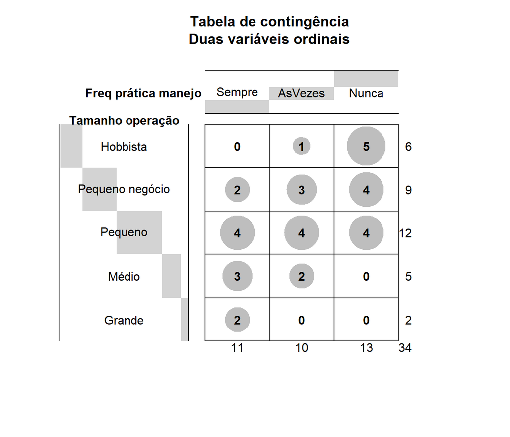

```r
gplots::balloonplot(t(Dados.tabela),
                    main ="Tabela de contingência\nDuas variáveis ordinais",
                    xlab ="Freq prática manejo",
                    ylab="Tamanho operação",
                    dotcolor="gray",
                    show.zeros=TRUE,
                    show.margins=TRUE)
```

```r
Dados <- DescTools::Untable(Dados.tabela)
Dados$Tamanho <- factor(Dados$Tamanho,
                        ordered=TRUE,
                        levels=c("Hobbista", "Pequeno negócio",
                                 "Pequeno", "Médio", "Grande"))
Dados$Frequência <- factor(Dados$Frequência,
                           ordered=TRUE,
                           levels=c("Nunca", "AsVezes", "Sempre"))

str(Dados)
```

```
'data.frame':   34 obs. of  2 variables:
 $ Tamanho   : Ord.factor w/ 5 levels "Hobbista"<"Pequeno negócio"<..: 2 2 3 3 3 3 4 4 4 5 ...
 $ Frequência: Ord.factor w/ 3 levels "Nunca"<"AsVezes"<..: 3 3 3 3 3 3 3 3 3 3 ...
 - attr(*, "out.attrs")=List of 2
  ..$ dim     : Named int [1:2] 5 3
  .. ..- attr(*, "names")= chr [1:2] "Tamanho" "Frequência"
  ..$ dimnames:List of 2
  .. ..$ Tamanho   : chr [1:5] "Tamanho=Hobbista" "Tamanho=Pequeno negócio" "Tamanho=Pequeno" "Tamanho=Médio" ...
  .. ..$ Frequência: chr [1:3] "Frequência=Sempre" "Frequência=AsVezes" "Frequência=Nunca"
```

```r
summary(Dados)
```

```
            Tamanho     Frequência
 Hobbista       : 6   Nunca  :13
 Pequeno negócio: 9   AsVezes:10
 Pequeno        :12   Sempre :11
 Médio          : 5
 Grande         : 2
```

```r
xtabs(~Tamanho+Frequência, data=Dados)
```

```
                 Frequência
Tamanho           Nunca AsVezes Sempre
  Hobbista            5       1      0
  Pequeno negócio     4       3      2
  Pequeno             4       4      4
  Médio               0       2      3
  Grande              0       0      2
```

```r
round(prop.table(Dados.tabela,
           margin=NULL),2)
```

```
                 Frequência
Tamanho           Sempre AsVezes Nunca
  Hobbista          0.00    0.03  0.15
  Pequeno negócio   0.06    0.09  0.12
  Pequeno           0.12    0.12  0.12
  Médio             0.09    0.06  0.00
  Grande            0.06    0.00  0.00
```

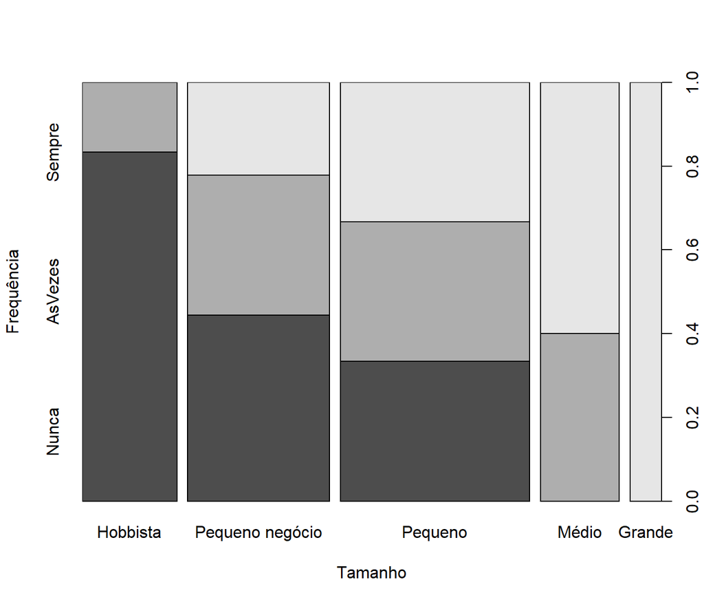

```r
spineplot(Dados.tabela)
```